# test_connection

Q1:  
There once was a man named Michael Finnegan,  
He had whiskers on his chinnegan,  
The wind came up and blew them in ag'in,  
Poor old Michael Finnegan (begin ag'in)

```python
print("There once was a man named Michael Finnegan,",end="")
print("He had whiskers on his chinnegan,",end="")
print("The wind came up and blew them in ag'in,",end="")
print("Poor old Michael Finnegan (begin ag'in)",end="")
```

```
There once was a man named Michael Finnegan,He had whiskers on his chinnegan,The wind came up and blew them in ag'in,Poor old Michael Finnegan (begin ag'in)
```

```python
print("There once was a man named Michael Finnegan,")
print("He had whiskers on his chinnegan,")
print("The wind came up and blew them in ag'in,")
print("Poor old Michael Finnegan (begin ag'in)")
```

```
There once was a man named Michael Finnegan,
He had whiskers on his chinnegan,
The wind came up and blew them in ag'in,
Poor old Michael Finnegan (begin ag'in)
```

```python
#I created a suitable name for the rhyme and didn't use my real name (๑‾ ꇴ ‾๑)
my_name = "Setsuna Rinnegan"
print("There once was a man named " + my_name + ",")
print("He had whiskers on his chinnegan,")
print("The wind came up and blew them in ag'in,")
print("Poor old " + my_name + " (begin ag'in)")
```

```
There once was a man named Setsuna Rinnegan,
He had whiskers on his chinnegan,
The wind came up and blew them in ag'in,
Poor old Setsuna Rinnegan (begin ag'in)
```

```python
my_name = input("Please type a name.")
print("There once was a man named " + my_name + ",")
print("He had whiskers on his chinnegan,")
print("The wind came up and blew them in ag'in,")
print("Poor old " + my_name + " (begin ag'in)")
```

```
Please type a name.Setsuna Rinnegan
There once was a man named Setsuna Rinnegan,
He had whiskers on his chinnegan,
The wind came up and blew them in ag'in,
Poor old Setsuna Rinnegan (begin ag'in)
```

```python
my_name = "Setsuna Rinnegan"
print("There once was a man named {},".format(my_name))
print("He had whiskers on his chinnegan,")
print("The wind came up and blew them in ag'in,")
print("Poor old {} (begin ag'in)".format(my_name))
```

```
There once was a man named Setsuna Rinnegan,
He had whiskers on his chinnegan,
The wind came up and blew them in ag'in,
Poor old Setsuna Rinnegan (begin ag'in)
```

```python
poems = ["There once was a man named Michael Finnegan,","He had whiskers on his chinnegan,","The wind came up and blew them in ag'in,","Poor old Michael Finnegan (begin ag'in)"]
for poem_line in poems:
    print(poem_line)
```

```
There once was a man named Michael Finnegan,
He had whiskers on his chinnegan,
The wind came up and blew them in ag'in,
Poor old Michael Finnegan (begin ag'in)
```

Q8:  
I think the most obvious advantage for "literate programming" is as its name suggests - programming in literate status. by using the high-level programming language that expressed in a manner closer to English prose,one of the human natural languages, the whole project can be managed and orgnized by the logic of more human-like style, not by computer style, which will be absolutely easier for programmers to express their thoughts and logic more smoothly. Programmers do not have to fit their thinking patterns with computers',and can liberate their thoughts of the project more freely. I think that should be one of the most obvious advantage for "literate programming".

Q9:  
In Q4, the two sentences that contains the name were split, we used a variable "my_name" to store the name string seperately. Then we connected the "my_name" string variable with the rest parts of the poem sentences string and pass the whole sentences string to print function respectively. By using this method, connecting string constant with string variable, it would be easily to change the specific part of sentence to what ever you want.

Q10:  
It would be always easy and conveninent for me to learn a new method or a new set of methods in a certain package by using the resources on the Internet.Taking Q6 as an example, I simply typed "python string format" on Google and found what I want among the links that the search engine gave to me. As for the specific link, here is the link that I have found my answer for Q6:  
https://pyformat.info/  
In this webpage, the author demonstrate the usage of format and "%" clearly by just using some examples, I made a screenshot of the core explanation part:

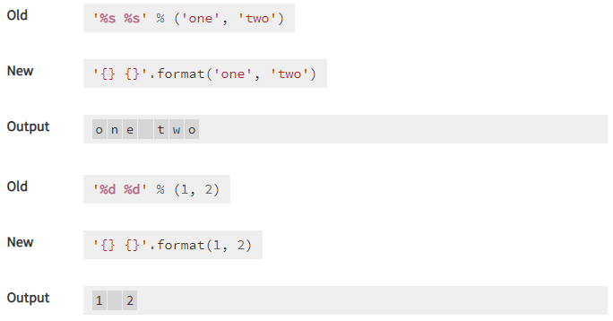

Just some small examples can let me understand the new function of "format" clearly. You can just replace the name part with a pair of braces and type specifically what you want to replace at the following format function. And also I have gained another similar way of replacing some certain parts of the string by using "%".  
Honestly, I have to say the learning new techniques part in Q6 is pretty easy for me. I think I have already understand the usage of format function since I have firstly finished reading the examples on the website above. Personally I did not come up with other questions that I have not understand yet or later improved understanding. This was just a process from 0 to 1 for me and 0.5 or 0.7 were not existed during the learning process. I think this is because my undergraduate background is computer science so I can understand or accept new similar concepts more quickly. In this Q6 case, the format function is very similar with the usage of printf function in C Language. No matter you use "{}" or "%d" or "%s" for replacement symbol, the idea of replacement remains the same. Though the format function is considered as "new", it is certainly not "totally new". There are always some similar cases there. I think summarizing the similarity among different programming languages can certainly help a lot for my programming language studying. However, if the situation has been changed to learn a completely new API or method that I have never seen the similar ones before, then it would definitely takes me more time, browsing more websites and searching more resources to find out the correct usage of it.  
So, in conclusion, this is my personal learning process for dealing with Q6, I wish it can be helpful for others too. (❁´▽`❁)